# Práctica 6 Prediccion

Garcia Giron A

30/11/2020

Existe relación? y si existe, intentaremos determinarla entre las series temporales de estas dos grandes de la industria automovilistica europea. partimos con de datos desde 2014.

### GARCH

"El modelo GARCH es un modelo autorregresivo generalizado que captura las agrupaciones de volatilidad de las rentabilidades a través de la varianza condicional.

En otras palabras, el modelo GARCH encuentra la volatilidad promedio a medio plazo mediante una autorregresión que depende de la suma de perturbaciones rezagadas y de la suma de varianzas rezagadas."

Eliminamos nas y calculamos la rentabilidad de los valores

Pocedemos a representar la volatilidad del modelos garch:

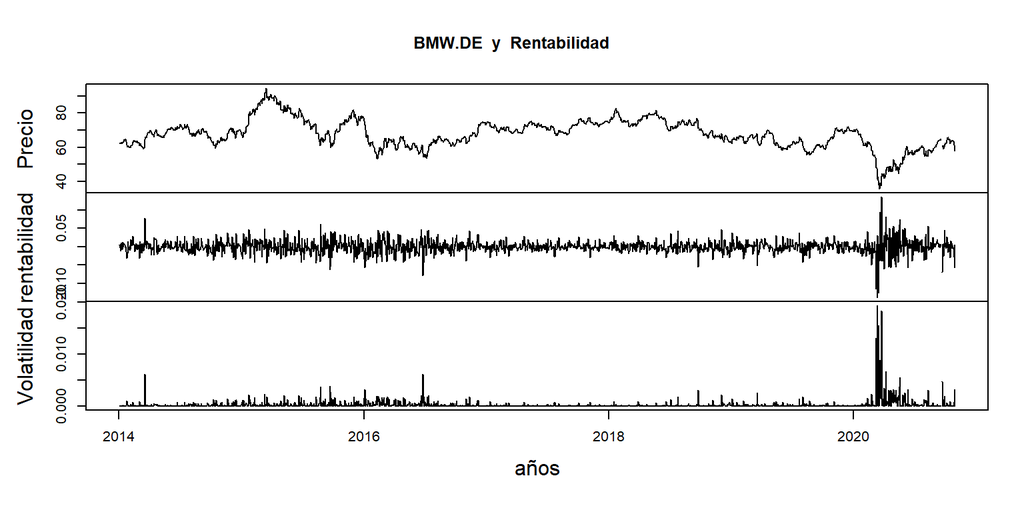

autocorrelaciones y la correlaciones parciales:

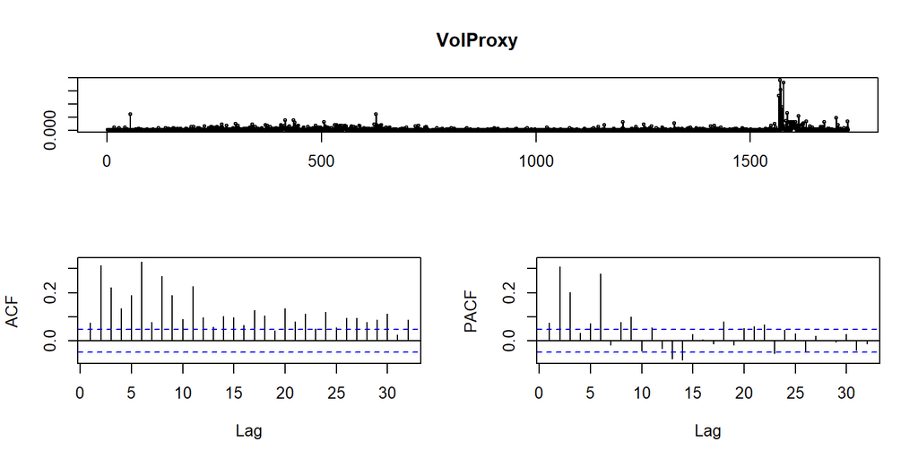

#duda siempre es ruido blanco ?? observamos como no es ruido blanco, por lo que deducimos que es un modelo gach